# Como ordenar y mostrar los datos, utilizando las graficas de R

Uria Archila David Uriel

20/12/2020

### En este pequeño tutorial, espero aprendan a realizar graficas en R, asi como a ordenar y presentar sus datos de una manera satisfactoria y agradable a la vista, comenzaremos con las diferentes funciones matematicas y despues saltaremos a las funciones trigonometricas, para concluir con una de las herramientas que nos presenta R para la organizacion de los datos, el Data Frame

## Comenzaremos con las funciones matematicas

### Primero, Definimos un dominio `x` para nuestras funciones

```r
x<-(-10:10)
```

### Ahoraa, como primer ejemplo, veremos como se crea la grafica de una funcion constante `f(x)=12`

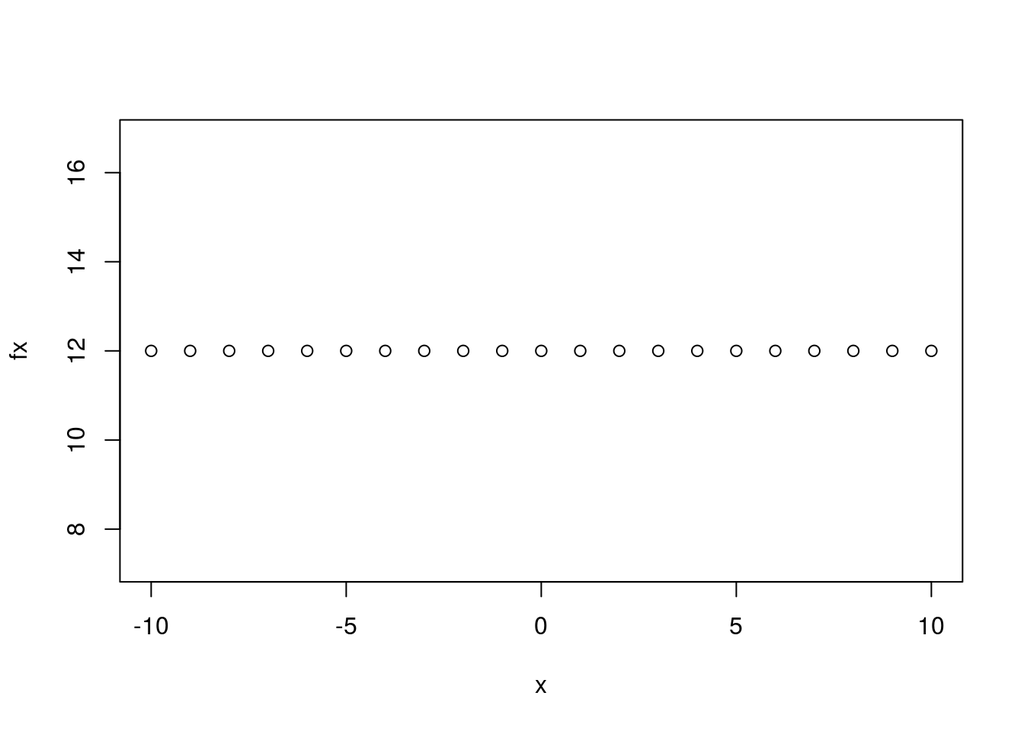

```r
fx<-rep(12, 21)
plot(x,fx)
```

### De manera similar al ejemplo anterior, ahora vamos a crear una funcin identidad de la siguiente manera `g(x)=x`, para crear su grafica, esta vez añadiremos `type="o"` al final, para que tambien se grafique la linea que una cada punto de la grafica

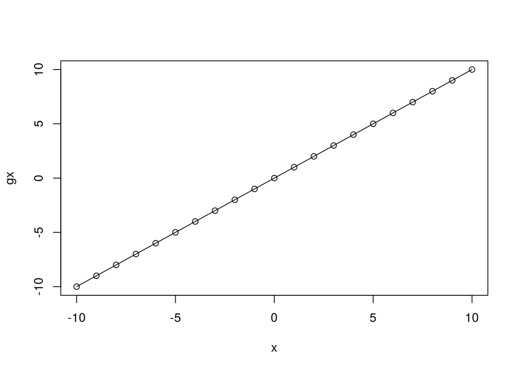

```r
gx<-x
plot(x,gx, type="o")
```

### Bien, ahora creemos y grafiquemos una funcion lineal, de la siguiente manera: y=mx+b ->`h(x)=5x+2` , mas al final añadiremos `type="l"` para que la grafica sea solo una linea

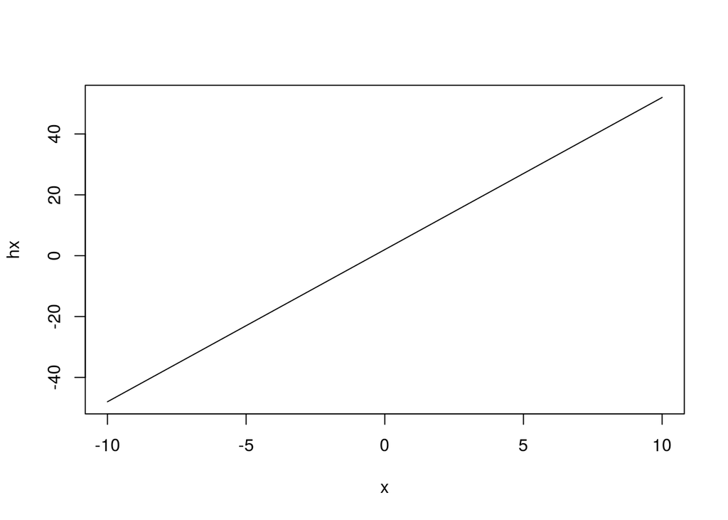

```r
hx<-5*x+2
plot(x,hx, type="l")
```

### Ahora toca la funcion cuadratica `i(x)=x^2`, esta vez, añadiremos nuevas opciones de personalizacion: utilizaremos `col="..."` para determinar cual sera el color de la grafica, pueden escribir el color deseado en ingles o bien añadir un numero al azar

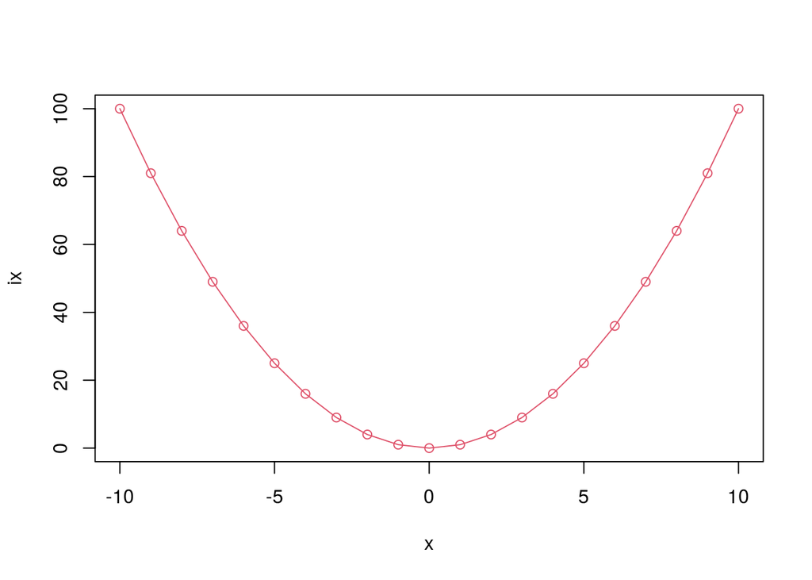

```r
ix<-x^2
plot(x,ix, col="98",type="o")
```

### Ahora haremos una funcion cubica `j(x)=x^3`, en este caso usaremos comandos para determinar el nombre de la grafica `main="Función cúbica"`, el nombre del eje x `xlab="Eje x"`, y el nombre para el eje y `ylab="Eje y"`

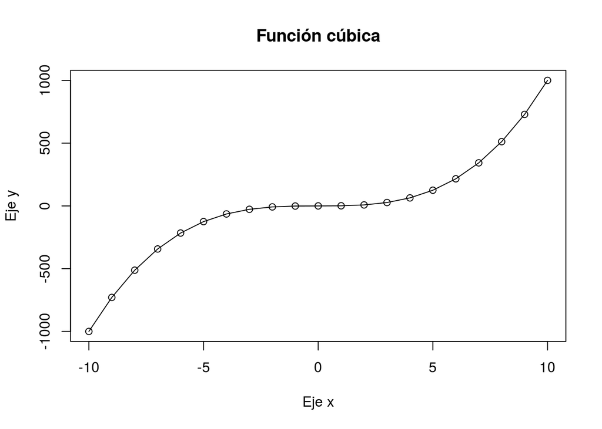

```r
jx<-x^3
plot(x,jx, main="Función cúbica", xlab="Eje x", ylab="Eje y", col="black", type="o")
```

### Turno de la funcion racional `k(x)=6/x`, vamos a añadir un piede de pagina para nuestra grafica usanto el domando `sub="..."`

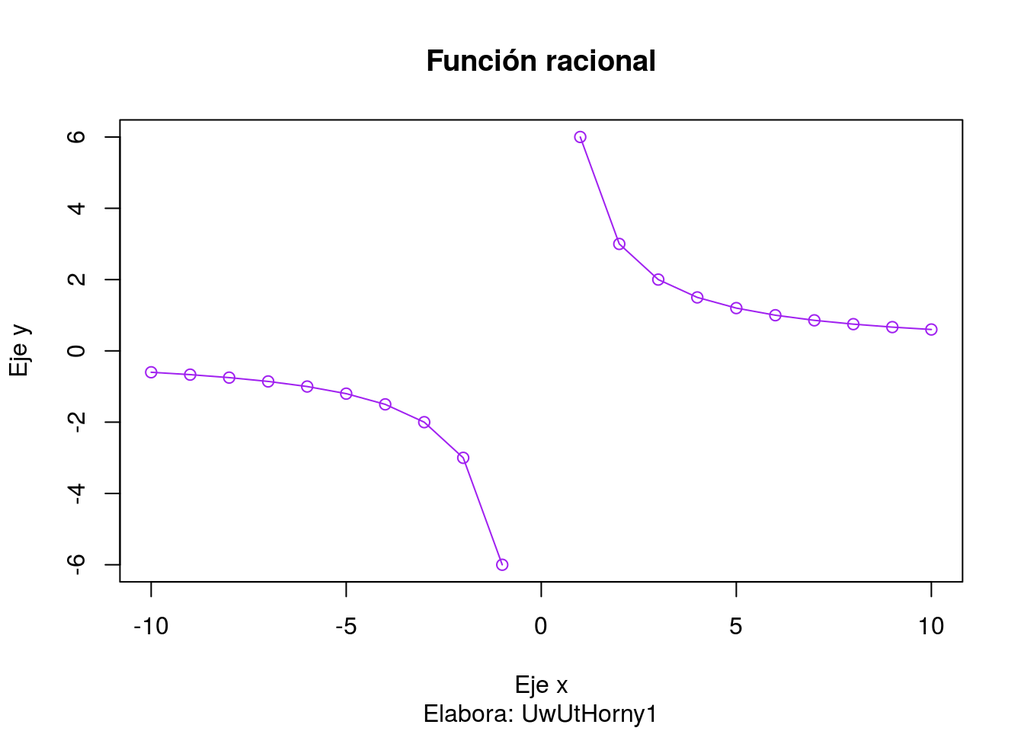

```r
kx<-6/x
plot(x,kx, main="Función racional", sub="Elabora: UwUtHorny1", xlab="Eje x", ylab="Eje y", col="purple", type="o")
```

### Continuemos con una funcion logaritmica `l(x)=log(x)`

```r
lx<-log(x)
```

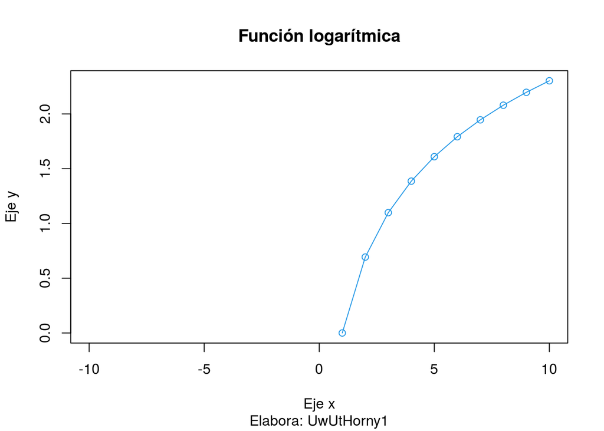

```r
plot(x,lx, main="Función logarítmica", sub="Elabora: UwUtHorny1",xlab="Eje x", ylab="Eje y", col="12", type="o")
```

### Ahroa probemos con una funcion exponencial `m(x)=7^x`

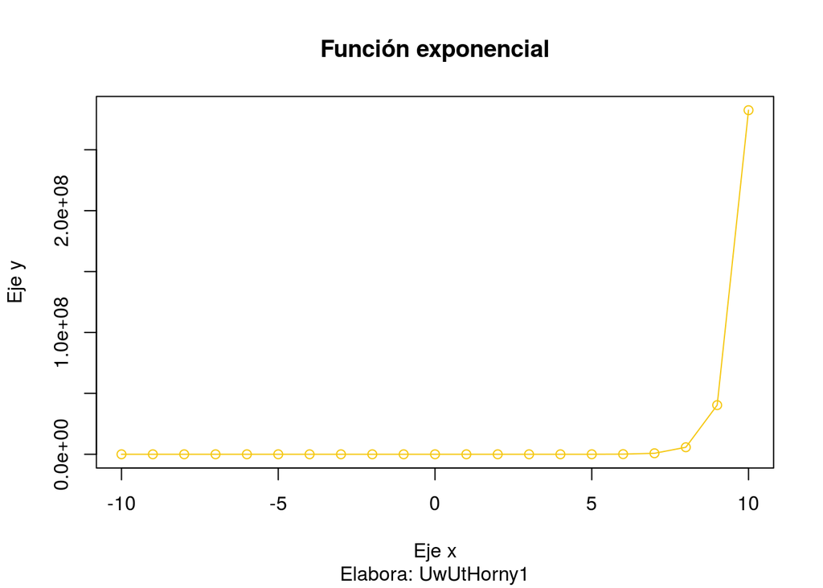

```r
mx<-7^x
plot(x,mx, main="Función exponencial", sub="Elabora: UwUtHorny1",xlab="Eje x", ylab="Eje y",col="87", type="o")
```

## Ya habiendo terminado con las funciones matematicas, vamos a dar el salto hacia las funciones trigonometricas

### primero sera la funcion Seno, la cual escribiremos de la siguiente forma `n(x)=sin(x)`

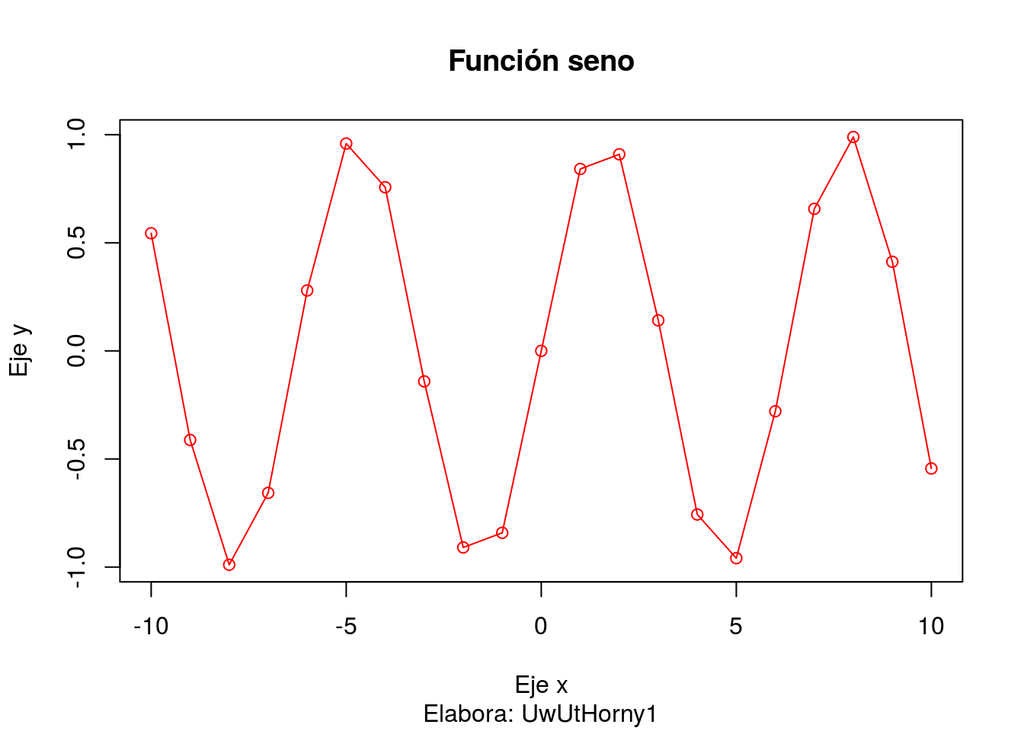

```r
nx<-sin(x)
plot(x,nx, main="Función seno", sub="Elabora: UwUtHorny1",xlab="Eje x", ylab="Eje y", col="red", type="o")
```

### Despues la funcion Coseno `o(x)=cos(x)`

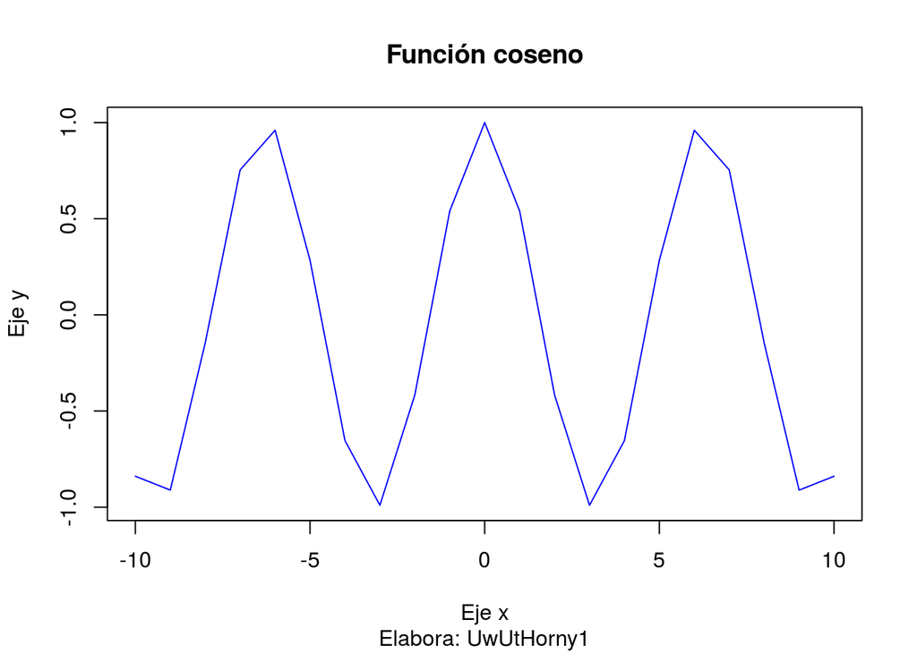

```r
ox<-cos(x)
plot(x,ox, main="Función coseno", sub="Elabora: UwUtHorny1",xlab="Eje x", ylab="Eje y", col="blue", type="l")
```

### continuemos con la funcion Tangente `p(x)=tan(x)`

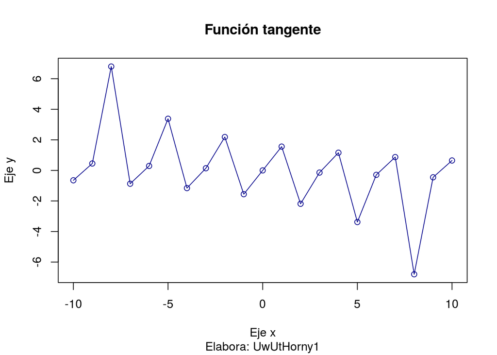

```r
px<-tan(x)
plot(x,px, main="Función tangente", sub="Elabora: UwUtHorny1", xlab="Eje x", ylab="Eje y", col="darkblue", type="o")
```

## Habiendo terminado con las funciones, pasemos a la organizacion de los datos con los que contamos

### Comenzaremos creando un cuadro de datos de todos nuestros resultados usando la funcion `data.frame(...)`

```r
total_de_datos<-data.frame(x,fx,gx,hx,ix,jx,kx,lx,mx,nx,ox,px)
total_de_datos
```

```
##      x fx  gx  hx  ix    jx         kx        lx           mx         nx
## 1  -10 12 -10 -48 100 -1000 -0.6000000       NaN 3.540133e-09  0.5440211
## 2   -9 12  -9 -43  81  -729 -0.6666667       NaN 2.478093e-08 -0.4121185
## 3   -8 12  -8 -38  64  -512 -0.7500000       NaN 1.734665e-07 -0.9893582
## 4   -7 12  -7 -33  49  -343 -0.8571429       NaN 1.214266e-06 -0.6569866
## 5   -6 12  -6 -28  36  -216 -1.0000000       NaN 8.499860e-06  0.2794155
## 6   -5 12  -5 -23  25  -125 -1.2000000       NaN 5.949902e-05  0.9589243
## 7   -4 12  -4 -18  16   -64 -1.5000000       NaN 4.164931e-04  0.7568025
## 8   -3 12  -3 -13   9   -27 -2.0000000       NaN 2.915452e-03 -0.1411200
## 9   -2 12  -2  -8   4    -8 -3.0000000       NaN 2.040816e-02 -0.9092974
## 10  -1 12  -1  -3   1    -1 -6.0000000       NaN 1.428571e-01 -0.8414710
## 11   0 12   0   2   0     0        Inf      -Inf 1.000000e+00  0.0000000
## 12   1 12   1   7   1     1  6.0000000 0.0000000 7.000000e+00  0.8414710
## 13   2 12   2  12   4     8  3.0000000 0.6931472 4.900000e+01  0.9092974
## 14   3 12   3  17   9    27  2.0000000 1.0986123 3.430000e+02  0.1411200
```

[output cut: 29 more lines]

### Ahora, graficaremos el cuadro de datos con la funcion `plot`

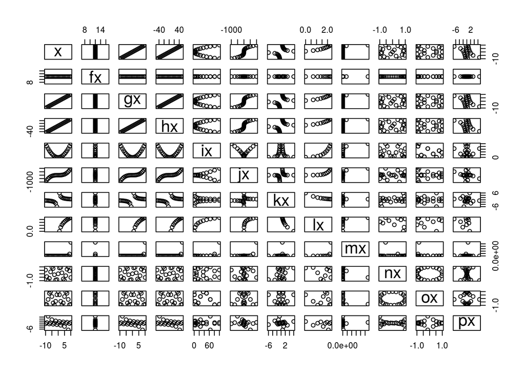

```r
plot(total_de_datos)
```

### Intentemos graficar columnas especificas, para esto escribiremos el nombre de nuestro data frame, seguido por el signo `$` y la columna deseada, recuerden que deben ser 2 columnas

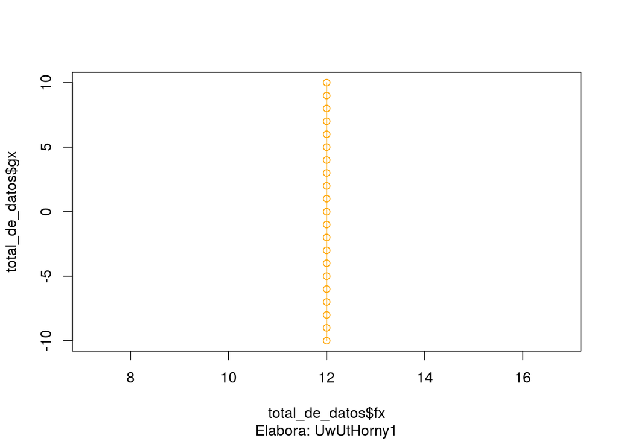

```r
plot(total_de_datos$fx,total_de_datos$gx, type = "o", col= "orange", sub= "Elabora: UwUtHorny1")
```

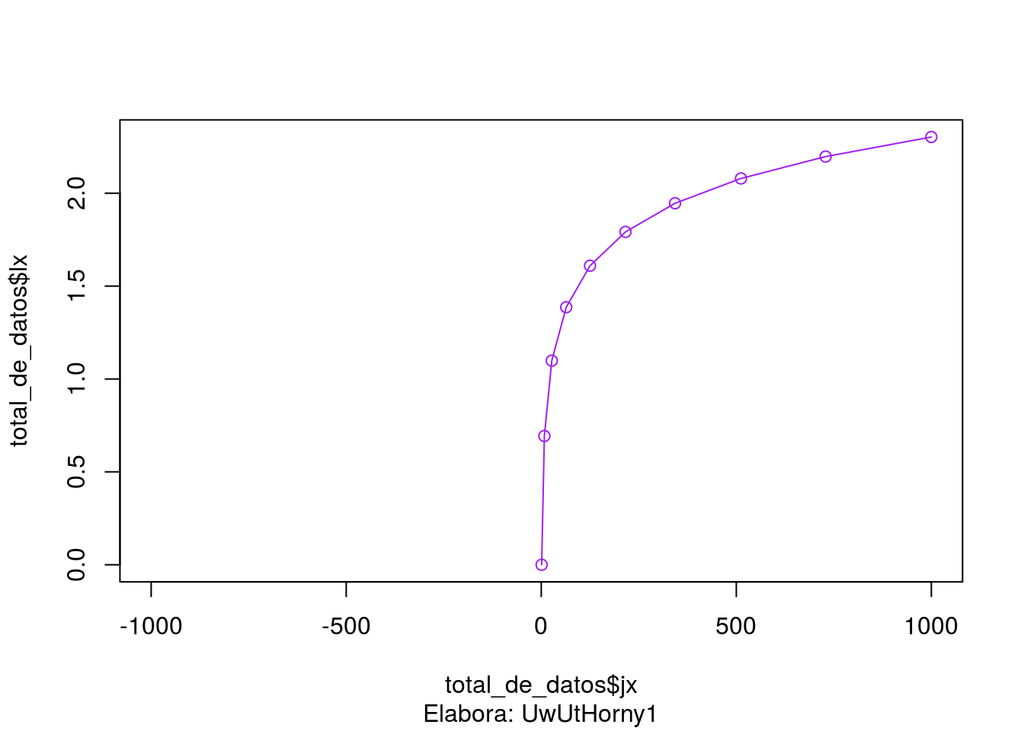

```r
plot(total_de_datos$jx,total_de_datos$lx, type = "o", col= "purple", sub= "Elabora: UwUtHorny1")
```

## A continuacion, presento un corto video en el cual se muestra como se puede realizar las mismas acciones en otra herramiente matematica conocida como Geogebra

[video not shown]